# Clustering of Social Media News using different vectorizations and algorithms

# Table of contents

1. Importing Required Libraries and Data
2. Preprocessing - creating clean text column
3. TF-IDF Clustering
4. Word2Vec Clustering
5. Doc2Vec Clustering
6. Observations

## 1. Importing Required Libraries and Data

```python
# Import libraries
import pandas as pd
import numpy as np
import re
import pickle
import matplotlib.pyplot as plt
import seaborn as sns
from nltk.tokenize import regexp_tokenize
from nltk.corpus import stopwords
from nltk.stem import WordNetLemmatizer
from sklearn.feature_extraction.text import TfidfVectorizer
from sklearn.cluster import KMeans
from sklearn.cluster import AgglomerativeClustering
from sklearn.cluster import AffinityPropagation
from sklearn.metrics.pairwise import cosine_similarity
from sklearn.manifold import MDS
%matplotlib inline
sns.set()
import random
random.seed(100)
```

```python
# Load data
df = pd.read_csv('News_SocialMedia.csv')
df = df[['Title', 'Headline', 'Topic']]
df.head(3)
```

|  | Title | Headline | Topic |
| --- | --- | --- | --- |
| 0 | Obama Lays Wreath at Arlington National Cemetery | Obama Lays Wreath at Arlington National Cemete... | obama |
| 1 | A Look at the Health of the Chinese Economy | Tim Haywood, investment director business-unit... | economy |
| 2 | Nouriel Roubini: Global Economy Not Back to 2008 | Nouriel Roubini, NYU professor and chairman at... | economy |

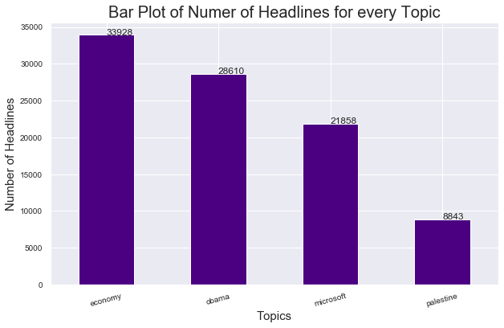

```python
def plot_col(a):
    ax = a.value_counts().plot(kind='bar', figsize=(10,6), color="indigo", fontsize=10,rot=15)
    ax.set_alpha(0.5)
    ax.set_title("Bar Plot of Numer of Headlines for every Topic", fontsize=20)
    ax.set_ylabel("Number of Headlines", fontsize=15);
    ax.set_xlabel("Topics", fontsize=15)
    for p in ax.patches:
        ax.annotate('{}'.format(p.get_height()), (p.get_x()+0.25, p.get_height()+2))
plot_col(df['Topic'])
```

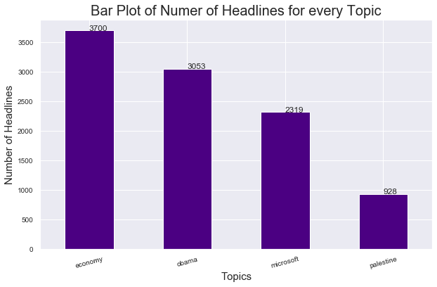

```python
#Since the data is huge let's take a random sample of 10k Headlines and do clustering on those headlines
df = df.sample(10000,random_state=1000)
#Distribution after sampling-- same as main distribution
plot_col(df['Topic'])
```

```python
#some columns contains na's dropping them
df.isna().sum()
```

```
Title       0
Headline    1
Topic       0
dtype: int64
```

```python
df=df.dropna()
```

## 2. Preprocessing - creating clean text column

```python
#function to clean text in a column returns list of rows as cleaned text
def Clean_df(df_Col):
    lemmatizer = WordNetLemmatizer()
    clean_list = []
    for text in df_Col:
        words = regexp_tokenize(text.lower(), r'[A-Za-z]+')
        words = [w for w in words if len(w)>1 and w not in stopwords.words('english')]
        words = [lemmatizer.lemmatize(w) for w in words]
        clean_list.append(' '.join(words))
    return clean_list
df['Clean_Headline'] = Clean_df(df['Headline'])
df.head(5)
```

|  | Title | Headline | Topic | Clean_Headline |
| --- | --- | --- | --- | --- |
| 20052 | Microsoft keeps its users' encryption keys sto... | Microsoft keeps a copy of users' recovery keys... | microsoft | microsoft keep copy user recovery key server d... |
| 64214 | Video: Barack Obama Steals Steph Curry's Moves... | Barack Obama and sometimes golf pal Steph Curr... | obama | barack obama sometimes golf pal steph curry sh... |
| 38514 | Proliant's Feilding plant expected to bolster ... | Economic Development Minister Steven Joyce, le... | economy | economic development minister steven joyce lef... |
| 5997 | Ex-Wall Street banker Simsek to lead Turkish e... | By Orhan Coskun ANKARA (Reuters) - Turkish Pri... | economy | orhan coskun ankara reuters turkish prime mini... |
| 47751 | Obama Is All Veto, No Action On Regulatory Reform | President Obama campaigned on a pledge to crea... | obama | president obama campaigned pledge create effic... |

```python
#backing up clean df
df_backup=df.copy()
```

## 3. Clustering using TF-IDF

```python
#create TF-IDF vectorizer with n-gram
def tfidf_ngram(df_col):
    from sklearn.feature_extraction.text import TfidfVectorizer
    tfidf_vect = TfidfVectorizer(analyzer='word', token_pattern=r'\w{1,}',ngram_range=(1,3),min_df=0.15,max_features=10000)#, max_features=5000)
    tfidf_matr =  tfidf_vect.fit_transform(df_col)
    return tfidf_matr
tfidf_matr=tfidf_ngram(df['Clean_Headline'])
```

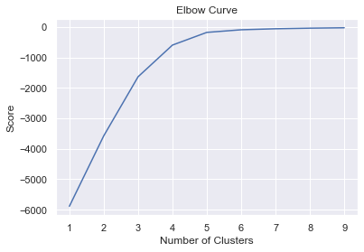

```python
# Plot Elbow Curve to find optimum "K" value
N = range(1, 10)
kmeans = [KMeans(n_clusters=i) for i in N]
score = [kmeans[i].fit(tfidf_matr).score(tfidf_matr) for i in range(len(kmeans))]
plt.plot(N, score)
plt.xlabel('Number of Clusters')
plt.ylabel('Score')
plt.title('Elbow Curve')
plt.show()
```

```python
#Since there in no change in score after 4 clusters.. taking 4 clusters to fit k means model
def k_means(input_mat):
    km = KMeans(n_clusters=4)
    km.fit(input_mat)
    km_labels = km.labels_
    km_clusters = km_labels.tolist()
    return km_clusters
df['cluster_kmeans_tfidf'] = k_means(tfidf_matr)
```

```python
def plot_cluster_2D_TSNE(vectors,clusters):
    #dim reduction using TSNE to plot clusters in 2D
    from sklearn.manifold import TSNE
    tsne = TSNE(n_components=2, init='random', random_state=42, perplexity=50)
    pos = tsne.fit_transform(vectors)
    xs, ys = pos[:, 0], pos[:, 1]

    # Set up cluster names using a dict
    cluster_names = {0: 'Cluster 1', 1: 'Cluster 2', 2: 'Cluster 3', 3: 'Cluster 4'}
    cluster_colors = {0: '#1b9e77', 1: '#d95f02', 2: '#7570b3', 3: '#e7298a'}

    # Plot clusters
    df_plot = pd.DataFrame(dict(x=xs, y=ys, label=clusters))
    groups = df_plot.groupby('label')
    fig, ax = plt.subplots(figsize=(17, 9))

    for name, group in groups:
        ax.plot(group.x, group.y, marker='o', linestyle='', ms=20,
                label=cluster_names[name], color=cluster_colors[name], mec='none')
        ax.set_aspect('auto')
        ax.tick_params(axis= 'x',  which='both', bottom='off', top='off', labelbottom='off')
        ax.tick_params(axis= 'y', which='both', left='off', top='off', labelleft='off')
    ax.legend(numpoints=1)
    plt.show()
    return
```

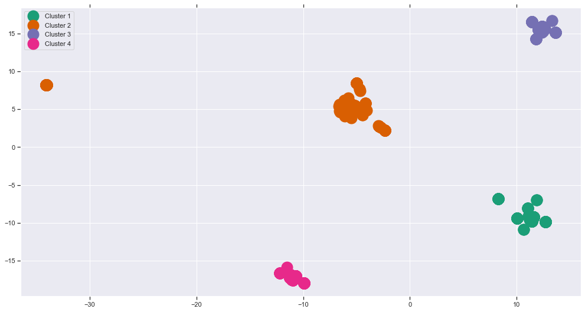

```python
plot_cluster_2D_TSNE(tfidf_matr[:1000],df['cluster_kmeans_tfidf'][0:1000])
```

## Agglomerative Clustering

```python
def agg_clust(input_mat):
    agglomerativeclustering = AgglomerativeClustering(n_clusters=4)
    ac_clusters = agglomerativeclustering.fit(input_mat)
    ac_labels = ac_clusters.labels_
    ac_clusters = ac_labels.tolist()
    return ac_clusters
simlr_matrix = (tfidf_matr * tfidf_matr.T).A
df['cluster_agglo_tfidf'] = agg_clust(simlr_matrix)
```

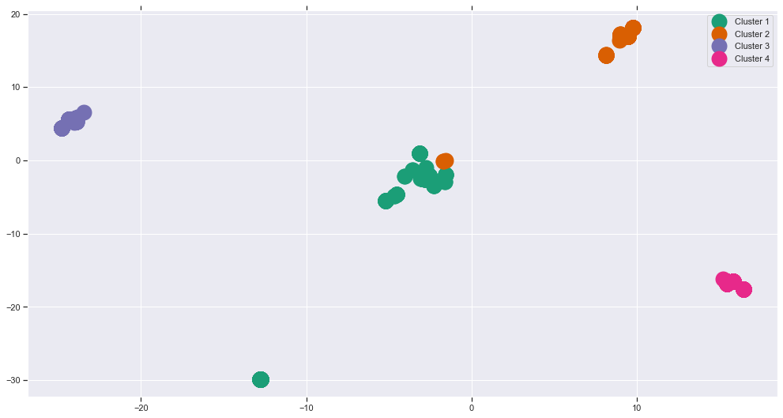

```python
plot_cluster_2D_TSNE(simlr_matrix[:1000],df['cluster_agglo_tfidf'][:1000])
```

## 5. Clustering using Doc2Vec

```python
tokenized_list1=Clean_df(df['Headline'])
```

```python
from gensim.models.doc2vec import Doc2Vec, TaggedDocument
docs = [TaggedDocument(doc, [i]) for i, doc in enumerate(tokenized_list1)]
d2v = Doc2Vec(docs, size=100, window=8, min_count=2, workers=8)
d2v.train(docs, total_examples=d2v.corpus_count, epochs=10)
vectors=d2v.docvecs.vectors_docs
```

### Kmeans Clustering

```python
df['cluster_kmeans_docvec'] = k_means(vectors)
```

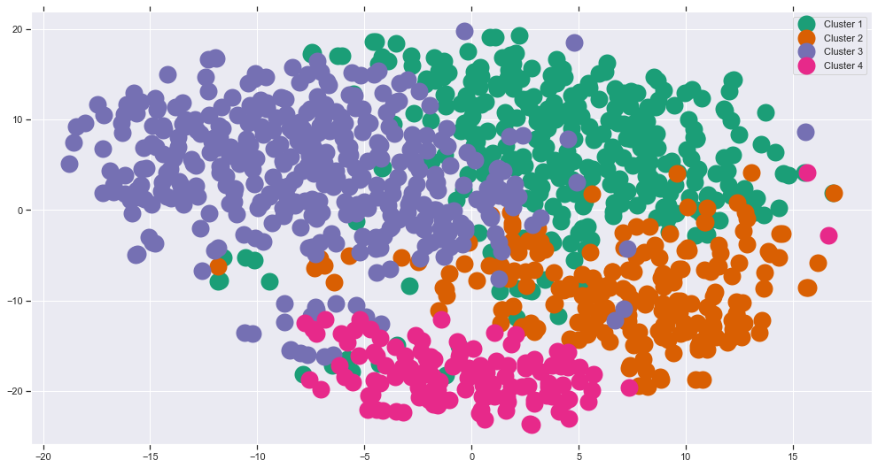

```python
plot_cluster_2D_TSNE(vectors[:1000],df['cluster_kmeans_docvec'][:1000])
```

### Agglomerative Clustering

```python
df['cluster_agglo_docvec'] = agg_clust(vectors)
```

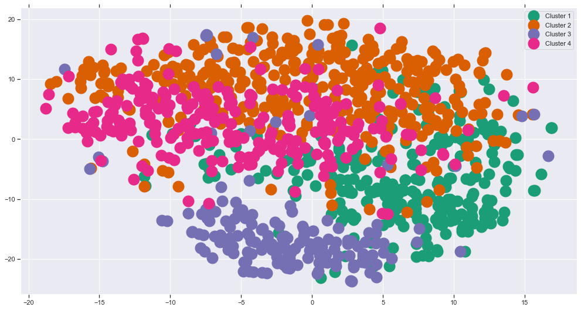

```python
plot_cluster_2D_TSNE(vectors[:1000],df['cluster_agglo_docvec'][0:1000])
```

## 4. Clustering using Word2 vec

```python
from gensim.utils import simple_preprocess
tokenized_list = [simple_preprocess(h) for h in df['Headline']]
import numpy as np
corpus = np.array(tokenized_list)

from gensim.models import Word2Vec
model = Word2Vec(corpus, size=100, window=8, min_count=2, sample=1e-3, sg=1, iter=5, workers=8)
vocab = set(model.wv.index2word)
```

Besides average to represent each doc with word vectors- I found this new feature vector creation where concatenate min word vector and maximum word vector to create a new min-max-word feature vector. According to this link and paper presented, this method will wordk good for short text - since the headline are short text docs implemented this method.

https://stats.stackexchange.com/questions/221715/apply-word-embeddings-to-entire-document-to-get-a-feature-vector

Reference:

Representation learning for very short texts using weighted word embedding aggregation. Cedric De Boom, Steven Van Canneyt, Thomas Demeester, Bart Dhoedt. Pattern Recognition Letters; arxiv:1607.00570. abstract, pdf. See especially Tables 1 and 2.

```python
def Min_max_word_vectors(words, model, vocabulary, num_features):
    max_feature_vector = np.zeros((num_features,), dtype="float64")
    min_feature_vector = np.zeros((num_features,), dtype="float64")
    for word in words:
        if word in vocabulary:
            max_feature_vector = np.maximum(max_feature_vector, model.wv[word])
            min_feature_vector = np.minimum(min_feature_vector, model.wv[word])
    feature_vector = np.concatenate((max_feature_vector,min_feature_vector))
    return feature_vector
features = [Min_max_word_vectors(sent_tokens, model, vocab, num_features) for sent_tokens in corpus]
min_max_features = np.array(features)
```

```python
df['kmeans_wordvec'] = k_means(min_max_features)
```

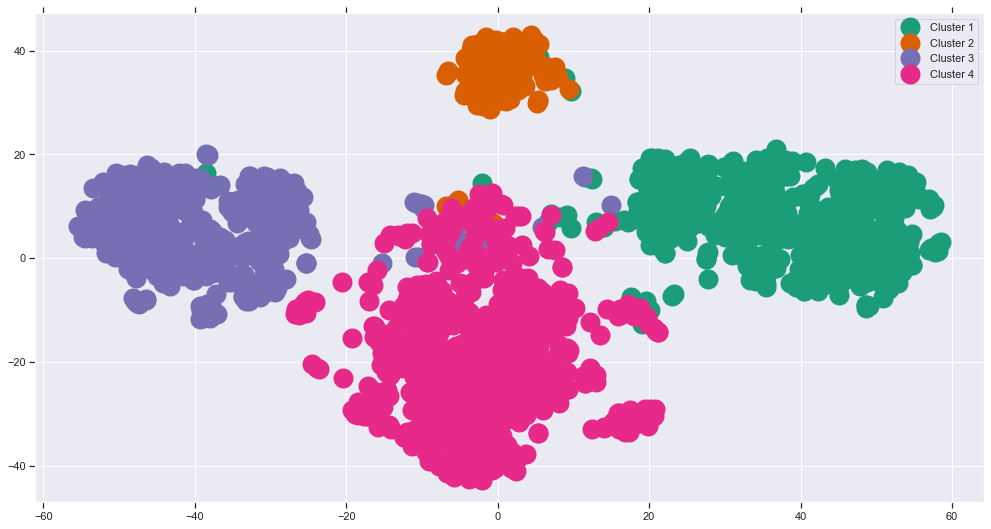

```python
plot_cluster_2D_TSNE(min_max_features[:2000],df['kmeans_wordvec'][0:2000])
```

### Agglomerative Clustering

```python
df['agglo_wordvec'] = agg_clust(min_max_features)
```

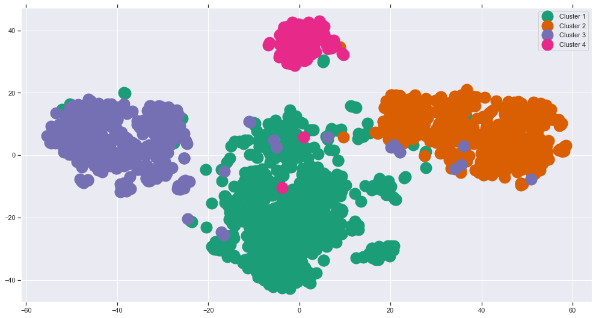

```python
plot_cluster_2D_TSNE(min_max_features[:2000],df['agglo_wordvec'][0:2000])
```

## 6. Observations

```python
df.head(5)
```

|  | Title | Headline | Topic | Clean_Headline | cluster_kmeans_tfidf | cluster_agglo_tfidf | cluster_kmeans_docvec | cluster_agglo_docvec | kmeans_wordvec | agglo_wordvec |
| --- | --- | --- | --- | --- | --- | --- | --- | --- | --- | --- |
| 20052 | Microsoft keeps its users' encryption keys sto... | Microsoft keeps a copy of users' recovery keys... | microsoft | microsoft keep copy user recovery key server d... | 3 | 2 | 0 | 1 | 2 | 2 |
| 64214 | Video: Barack Obama Steals Steph Curry's Moves... | Barack Obama and sometimes golf pal Steph Curr... | obama | barack obama sometimes golf pal steph curry sh... | 1 | 0 | 0 | 1 | 0 | 1 |
| 38514 | Proliant's Feilding plant expected to bolster ... | Economic Development Minister Steven Joyce, le... | economy | economic development minister steven joyce lef... | 0 | 1 | 1 | 0 | 3 | 0 |
| 5997 | Ex-Wall Street banker Simsek to lead Turkish e... | By Orhan Coskun ANKARA (Reuters) - Turkish Pri... | economy | orhan coskun ankara reuters turkish prime mini... | 0 | 1 | 1 | 0 | 0 | 0 |
| 47751 | Obama Is All Veto, No Action On Regulatory Reform | President Obama campaigned on a pledge to crea... | obama | president obama campaigned pledge create effic... | 1 | 0 | 0 | 1 | 0 | 1 |

```
---------------------------------------TFIDF-------------------------------------------------
```

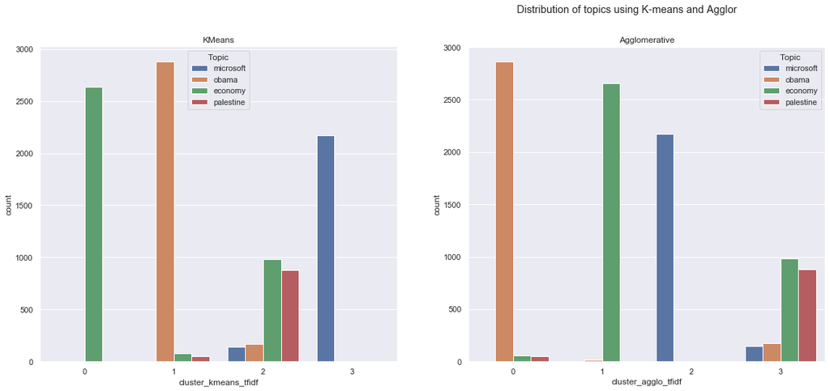

```
---------------------------------------Doc2vec---------------------------------------
```

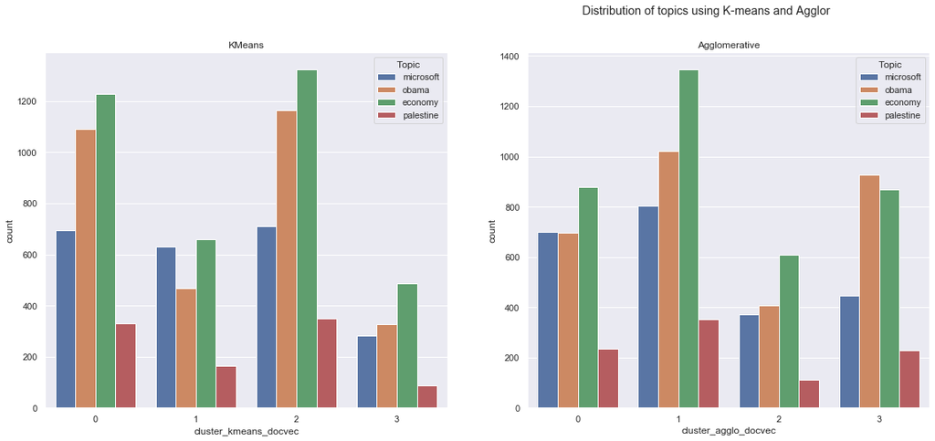

```
---------------------------------------Word2vec---------------------------------------
```

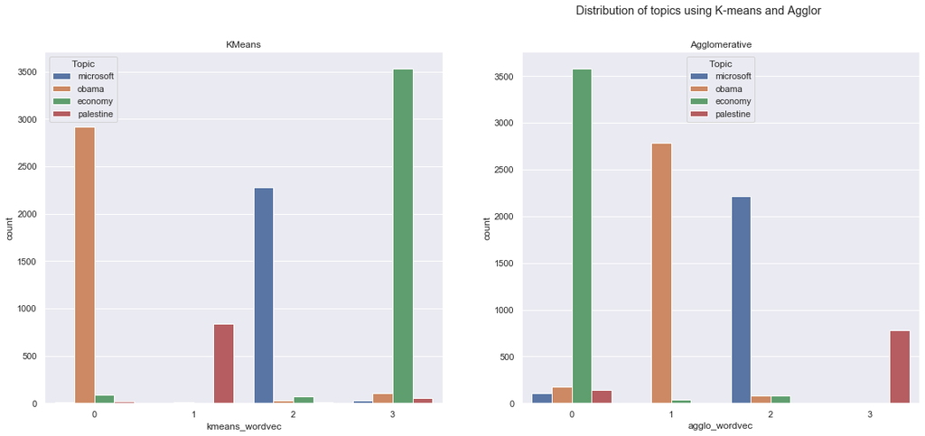

```python
# Plot of distribution of topics in clusters with different methods
def distplot(X1,X2,Y):
    plt.figure(figsize=(30, 8))
    plt.subplot(131)
    sns.countplot(data=df,x=X1,hue=Y)
    plt.title('KMeans')

    plt.subplot(132)
    sns.countplot(data=df,x=X2,hue=Y)
    plt.title('Agglomerative')
    plt.suptitle('Distribution of topics using K-means and Agglor')
    plt.show()
print("---------------------------------------TFIDF-------------------------------------------------")
distplot('cluster_kmeans_tfidf','cluster_agglo_tfidf','Topic')
print("---------------------------------------Doc2vec---------------------------------------")
distplot('cluster_kmeans_docvec','cluster_agglo_docvec','Topic')
print("---------------------------------------Word2vec---------------------------------------")
distplot('kmeans_wordvec','agglo_wordvec','Topic')
```

Observations:

- With 6 type of combinations- using TF-IDF,Word2vec and Doc2vec, there results are quite different.
- Doc2vVec with neither K-Means nor Agglomerative clustering algorithms performed well. They both failed to cluster topics.
- TF-IDF comparitevely performed well than Doc2vec but failed to cluster topics in 1-2 categories with both K-means and agglomerative.
- Word2Vec performed the best compared to both TF-IDF and Doc2Vec, Compared to K-means Agglomerative performed well and clustered topics appropriately with the sample.

Word2Vec with K-means performed very Well.

```python
# Exporting to csv file
df = df.drop(columns=['Clean_Headline'])
df.to_csv('Assignment5.csv')
```

```python
#extra
```

```python
# Plot clusters of a subset - 1000 records
def plot_cluster_2D_MDS(vector,cluster):
    from sklearn.metrics.pairwise import cosine_similarity
    distance = 1 - cosine_similarity(vector)

    from sklearn.manifold import MDS
    mds = MDS(n_components=2, dissimilarity="precomputed", random_state=42)
    pos = mds.fit_transform(distance)
    xs, ys = pos[:, 0], pos[:, 1]

    # Set up cluster names using a dict
    cluster_names = {0: 'Cluster 1', 1: 'Cluster 2', 2: 'Cluster 3', 3: 'Cluster 4'}
    cluster_colors = {0: '#1b9e77', 1: '#d95f02', 2: '#7570b3', 3: '#e7298a'}

    # Plot clusters
    df_plot = pd.DataFrame(dict(x=xs, y=ys, label=cluster))
    groups = df_plot.groupby('label')
    fig, ax = plt.subplots(figsize=(17, 9))

    for name, group in groups:
        ax.plot(group.x, group.y, marker='o', linestyle='', ms=20,
                label=cluster_names[name], color=cluster_colors[name], mec='none')
        ax.set_aspect('auto')
        ax.tick_params(axis= 'x',  which='both', bottom='off', top='off', labelbottom='off')
        ax.tick_params(axis= 'y', which='both', left='off', top='off', labelleft='off')
    ax.legend(numpoints=1)
    plt.show()
    return
```

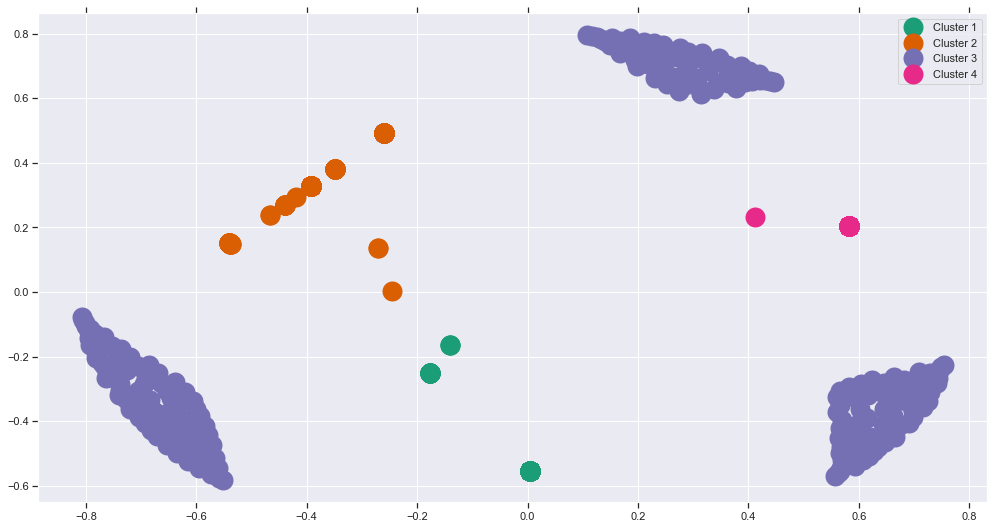

```python
plot_cluster_2D_MDS(tfidf_matr[0:1000],df['cluster_kmeans_tfidf'][0:1000])
```